# Indel Signature InsDel19a

# InsDel19a

(corresponds to 83-type signature C_ID19 )

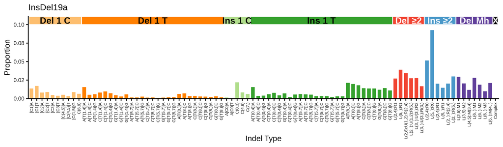

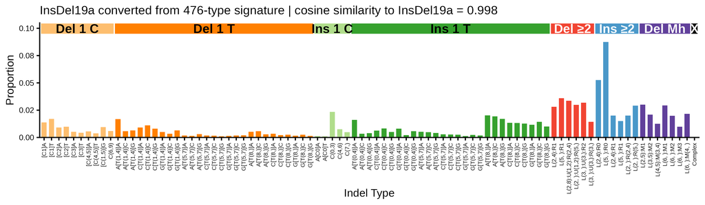

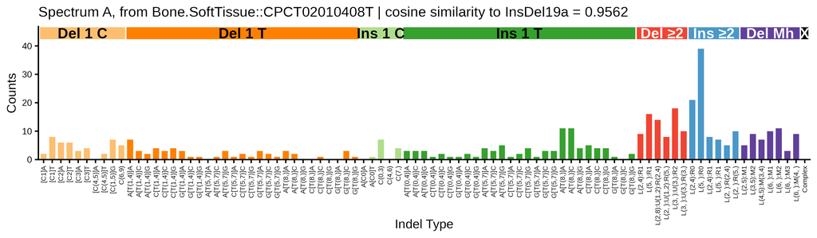

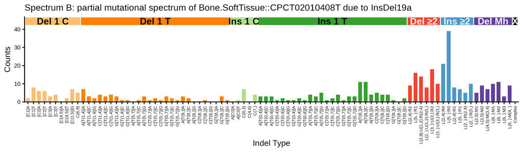

[figure not shown]

## 476-type representations corresponding to InsDel19a

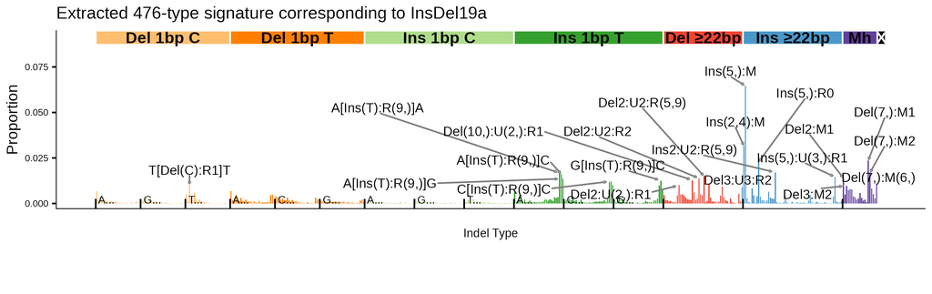

476-type spectrum of the supporting tumor Bone.SoftTissue::CPCT02010408T; cosine similarity to the extracted 476-type signature is 0.9038

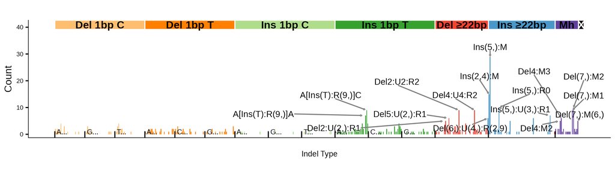

## 83-type signature corresponding to InsDel19a ( C_ID19 )

**Click here to show 83-type plots**

**Note**

The 476-type InsDel19b extraction collapses to 83-type signature close to C_ID19, with the addition of a small proportion of singe-T deletions in the context long poly-T contexts.

The 476-type InsDel1c extraction collapsed to the 83-type representation has single-C and single-T deletions that are absent C_ID19

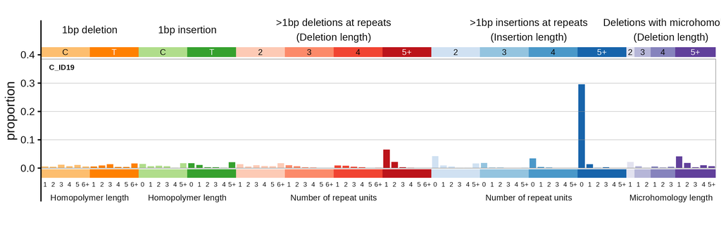

83-type signature converted from 476-type signature corresponding to InsDel19a | cosine similarity to C_ID19: 0.5834

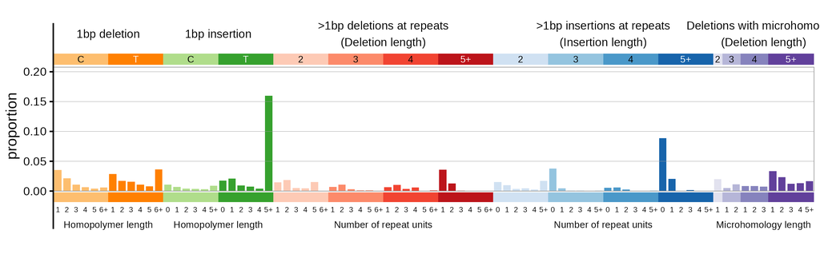

**Click here to see with insertions and deletions of T in long poly-T suppressed**

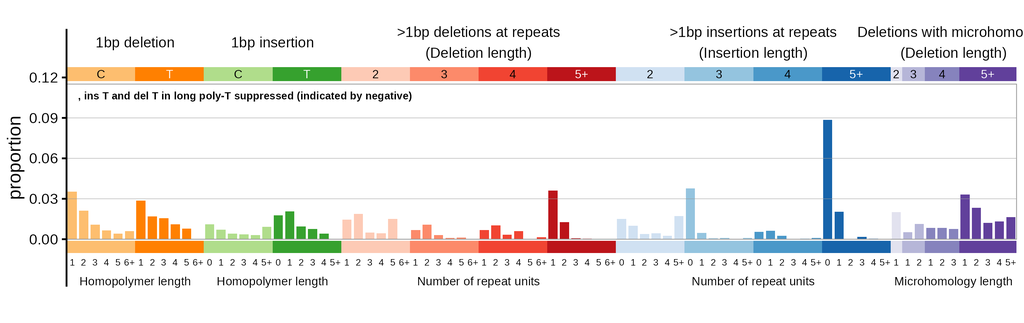

83-type spectrum of the supporting tumor Bone.SoftTissue::CPCT02010408T | cosine similarly to C_ID19: 0.5789

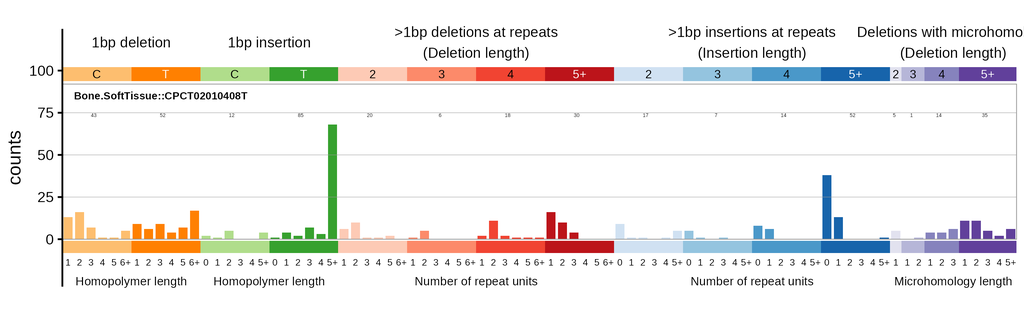

**Click here to see with insertions and deletions of T in long poly-T suppressed**

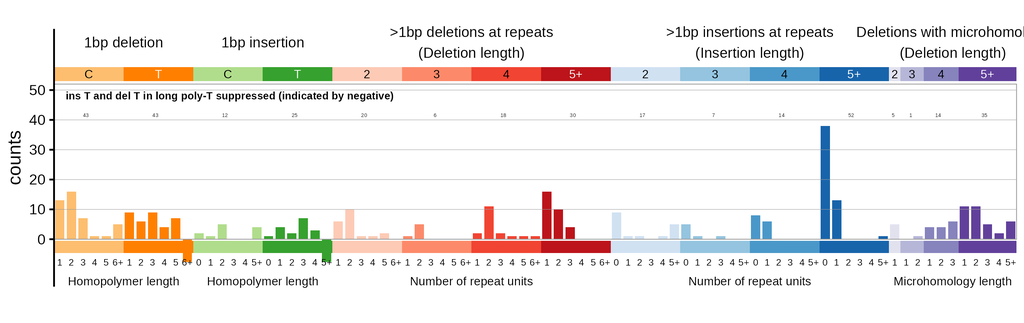

### Similar COSMIC signatures

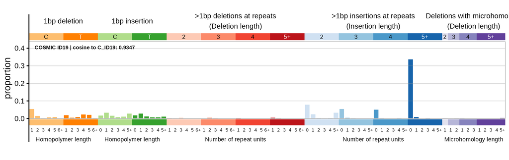